# An Updated Assessment of Party-Driven Racial Attitude Change among Whites

Posted 2025-06-13

### In Brief

- White racial attitude polarization since 2016 remains a mix of party switching and attitude change, but this appears isolated to a measure of whites’ explanations for Black Americans’ status and not one capturing relative favorability judgments.
- Scholars should thus be careful interpreting 1) hypothesis tests using cross-sectional data and 2) associations between racial attitudes or partisanship and outcomes of interest.

### Details

It is commonplace to identify an increasingly tight connection between the views white Americans hold about Black people and their partisanship. These trends appear in snapshots of the U.S. public [since the 1980s](https://academic.oup.com/poq/article/86/S1/576/6617224) and in work tracking the attitudes of the same respondents [between 2011 and 2024](https://democracyfund.org/idea/pushed-and-pulled/). While the conventional view is that this comes from people switching parties, I previously offered [evidence](https://www.amengelhardt.com/files/engelhardt_PID_racial_attitudes_bjps.pdf) that since 2008, this conventional view is complemented by one where some whites are actually changing their attitudes to fit with their partisanship. These shifts [appear sincere](https://www.amengelhardt.com/files/engelhardt_attitude_change_ajps.pdf), and have paid off in white Democrats increasingly favoring [Black politicians](https://osf.io/preprints/osf/bjhz2) in part out of a desire to [address racial inequality](https://www.cambridge.org/core/journals/american-political-science-review/article/white-democrats-growing-support-for-black-politicians-in-the-era-of-the-great-awokening/CD6861093C88839E6955F4BCC5BEA339). These shifts, too, may help explain partisan polarization on [child socialization](https://doi.org/10.1017/S0003055424000273) following the 2020 Black Lives Matter protests and ensuing debate about school curricula.

But the argument I advanced hinged on the background social and political context, with the evidence accumulated ending in 2016. And much has changed since then. So, with the release of the 2024 [American National Election Study](https://electionstudies.org/data-center/2024-time-series-study/), I found it useful to update my analysis with these new data. I also apply a statistical method more appropriate for identifying attitudinal shifts [within individuals](http://doi.apa.org/getdoi.cfm?doi=10.1037/a0038889).

While preliminary until the ANES finalizes the 2024 release, I find a continued bidirectional relationship between whites’ views of Black Americans and their partisanship. But this is isolated to a racial attitude measure that divides respondents according to how much they attribute Black Americans’ social and economic status to individual effort or systemic discrimination.[^1] One probing how people think generally about Black Americans in relation to white Americans sees some evidence of party-driven attitude change, and no evidence of party switching on the basis of the attitude.

While this has many substantive and theoretical implications, I want to note first some empirical ones. First, it reinforces the need for [apporpriate research designs](https://www.amengelhardt.com/files/engelhardt_race_votes_qjps.pdf) when wanting to explain (changing) cross-sectional correlations. Second, it requires researchers be attuned to the fact that racial attitudes or partisanship can matter indirectly, even if they do not carry significant coefficients in a regression.[^2] Racial attitudes contain whites’ politics and whites’ partisan preferences contain their racial attitudes. Showing that racial attitudes, measured in 2020 or 2024, predict some policy opinion or antidemocratic outlook isn’t a pure assessment of that attitude. It’s also capturing white folks’ political commitments, even if those political commitments are controlled for in the model, because the influence occurred temporally prior to their assessment.

In my view, the best solution is to use multiple racial attitude measures to test the same hypothesis, and think carefully about what one’s predictors incorporate. Follow [Telser’s](https://press.uchicago.edu/ucp/books/book/chicago/P/bo22961444.html) lead and use racial attitudes measured temporally prior to when the outcome of interest is measured. Or if one wants to take advantage of the attitude after it has changed, be clear about these attitudes’ ingredients.

These changes also open the door for interesting new research opportunities around partisanship and coalition construction. We think about preference for coalition partners as often preceding party selection. This evidence points to outlooks toward coalition partners developing as a consequence of party membership.

### Technical Information

##### Racial Attitude Trends: 2016-2024

One way we can see attitude change as part of polarizing racial attitudes is to rule out the alternative party-switching story by looking at whether we see changing racial attitudes among people who remain in a given party over time. I show this with data from the American National Election Study’s 2016-2020-2024 panel. Respondents to the web version of the 2016 survey were invited to complete the 2020 and 2024 versions over the web on their own.

The figure below looks at the racial attitudes of white Democrats and white Republicans **who remained** Democrats or Republicans in this eight-year window. Fluctuation in attitudes is then definitionally change because we are looking at the same people over time and, by looking at consistent partisans, looking only at those who could possibly update their beliefs.

I use two measures. The first is racial resentment, an orientation concerning [explanations for Black Americans’ status](https://www.journals.uchicago.edu/doi/abs/10.1086/693907). Higher values of racial resentment are consistent with more negative attitudes toward Black Americans. But this is importantly not a [measure of prejudice](https://press.uchicago.edu/ucp/books/book/chicago/D/bo3620441.html), instead capturing a conjunction of prejudice and values like individualism and egalitarianism that produces a [perspective](https://papers.ssrn.com/sol3/papers.cfm?abstract_id=3602502) whites bring to understand racial inequality. I thus complement this with a more direct measure of prejudice that uses respondents’ ratings of whites and Blacks on 101-point feeling thermometers, subtracting views of Blacks from view of whites to emphasize relative preference and address interpersonal incomparability issues inherent in rating scales.

Both plots demonstrate change from 2016 to 2024, with this is visible most clearly for Democrats. In 2016, white Democrats’ racial resentment averaged 0.33 on a 0-1 scale, decreasing to 0.25 in 2020, before moving back to 0.3 in 2024. We see a similar decline and reversion among Republicans, but this is more muted. While they average 0.72 in 2016, they end up at 0.7 in 2024.

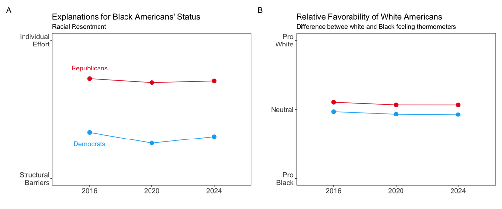

**Trends in Racial Attitudes among Consistent Partisans**.

A similar story holds on the favorability measure. White Democrats’ relative favorability toward whites averaged 0.48 on a 0-1 scale and decreased subsequently, down to 0.46 in 2024. We see a similar decline among Republicans. They score at 0.55 in 2016, with this decreasing to 0.53 in 2024.

What these plots do not show, however, is if these changes over time are statistically meaningful, or if they are directly connected to partisanship. What they show is that the sorts of white Americans who remained partisans across time on average saw shifting attitudes.

##### Updating Bidirectionality Test with New Data and Method

The figure below reports the parameter estimates from two different models: one using racial resentment (top panel) and the other using relative white favorability (bottom panel). The left portion of each figure shows that, on average through this period, both racial attitudes correlate highly with partisanship, and especially so for racial resentment.

The panels also show that a bidirectional relationship exists in this period, but one limited to racial resentment. The right portion of Panel A reports estimated autoregressive (arrows pointing left to right) and cross-lagged (diagonal arrows) effects. These effects show whether an individual’s unique state in one period carried over into the next period. The estimates show carryover effects for both racial resentment and partisanship, where period-specific fluctuations persist over time. This is consistent with strengthening partisan attachments in the polarization literature. It is also informative that racial resentment itself changed over time, separate from any influence from partisanship.

The diagonal arrows show that these fluctuations also influenced the other orientation. Temporary deviations in 2016 from long-run partisanship in this period influenced racial resentment in 2020, and vice versa for racial resentment to partisanship. This is evidence for a bidirectional relationship. Substantively, this means that heightened Republican partisanship translated into more negative attitudes or heightened Democratic partisanship translated into more positive views. Similarly, temporarily increased racial resentment led white Americans to strengthen their attachments to the Republican party while decreases led whites to the Democratic party. And this pattern persisted between 2020 and 2024.

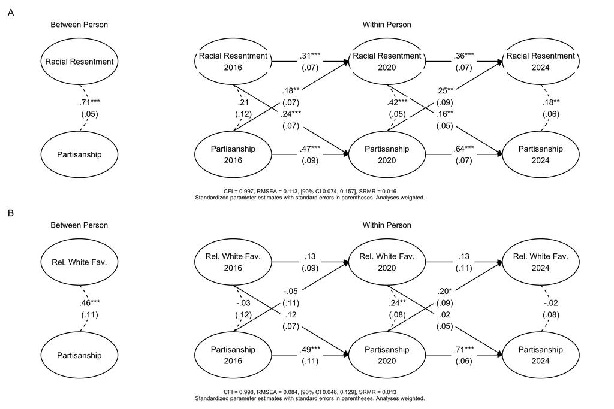

**Individual-level change in Partisanship and Racial Attitudes. Results from random intercepts cross-lagged panel model.**

The bottom panel shows limited bidirectional influence specifically or temporal influence generally when using the favorability measure. While partisanship strengthens over time, no such pattern holds for favorability. The estimates also only point to one significant cross-lagged effect, with deviations in partisanship in 2020 having a downstream effect on favorability in 2024–heightened Republicanism aligns with greater pro-White favorability over time. While previously I found evidence for dynamic relations between partisanship and affect, that could be due to the specific contexts I considered or the estimation strategy used.

[^1]: This measure, known as [racial resentment](https://press.uchicago.edu/ucp/books/book/chicago/D/bo3620441.html), has a [contentious history](https://press.uchicago.edu/ucp/books/book/chicago/R/bo3617330.html). But I use it to take seriously its intention to capture the [“political role of whites’ racial attitudes,”](https://psycnet.apa.org/record/1988-97566-004) a view which can account for its clearer connections with partisanship than other manifestations of racial attitude.
[^2]: Dan Hopkins’s [*Stable Condition*](https://www.russellsage.org/publications/stable-condition) offers a nice treatment of this inferential challenge in the context of healthcare attitudes.
[^3]: State and trait could be differentiated as, for instance, feeling anxious versus having an anxious personality. The model asks whether temporary deviations in anxiety, say slightly heightened levels, have future consequences.